# Class Project

Final Report

Branson T Fausey

Sunday, 8th December, 2024

# Research Question:

*How has Pennsylvania’s deer population changed over time, and how does it compare to other states’ populations? How about compared to other popular game animals in Pennsylvania?*

- For clarification, my main interest is the white-tailed deer species, but my analyses and descriptions will include other species of deer, mainly species native to the United States such as white-tailed and mule deer.

## Data Sources:

- [Deer Friendly](https://www.deerfriendly.com/)
- [Pennsylvania Deer Harvest 1915 to 2020](https://docs.google.com/spreadsheets/d/1C8gSJWomCEdPSvHPHm7UVd_oGQU6gmsm/edit?gid=1959951972#gid=1959951972)
- [US Deer Population Long-term Chart](https://docs.google.com/spreadsheets/d/1nuAUVkXsp1HkhIlPsiNFG_BzyO5HOYdS01jqrYXX-FY/edit?gid=1580702380#gid=1580702380)
- [Texas Deer Population 2000 to 2021](https://docs.google.com/spreadsheets/d/1GLy-Knmp_IzJALFd01E2bJCG8h0Ow3I4S9nCl7PDnbE/edit?gid=0#gid=0)
- [Nevada Mule Deer Population](https://docs.google.com/spreadsheets/d/1ZIL0-G_3x3nTbz_pz135ttUocQLy2OuIecnBJgdgpIM/edit?gid=0#gid=0)

Texas is reported to host the largest deer population in the country, while Nevada is reported to have the least amount of deer for a state in the contiguous US.

The PA and US data sources are cluttered with images and descriptions that follow no sense of data organization, so without changing any values, I simply remove the unnecessary bits in the Excel files to import.

The TX and NV data sets can be read-in okay without adjustments.

All data is collected by government entities and compiled by Deer Friendly.

# Data Import and Initial Wrangling

```r
# data import
PAdeerharvest <- read_excel("PAdeerharvest.xlsx")
USdeerpop <- read_excel("USdeerpop.xlsx")
TXdeerpop <- read_excel("TXdeerpop.xlsx")
NVdeerpop <- read_excel("NVdeerpop.xlsx")
```

```r
# inspecting data intake
PAdeerharvest %>%head()
```

| year | antlered deer | antlerless deer | total deer | bear | spring turkey | fall turkey | antlered elk | antlerless elk | total elk |
| --- | --- | --- | --- | --- | --- | --- | --- | --- | --- |
| *2020 | NA | NA | NA | 3621 | NA | NA | NA | NA | NA |
| *2019 | 163240 | 226191 | 389431 | 4657 | 37286 | 9006 | 34 | 95 | 129 |
| *2018 | 147750 | 226940 | 374690 | 3153 | 40303 | 9129 | 27 | 74 | 101 |
| *2017 | 163750 | 203409 | 367159 | 3438 | 38101 | 9168 | 27 | 79 | 106 |
| *2016 | 149460 | 183794 | 333254 | 3530 | 35966 | 10708 | 27 | 79 | 106 |
| *2015 | 137580 | 178233 | 315813 | 3748 | 41180 | 14861 | 22 | 65 | 87 |

```r
USdeerpop %>% head()
```

| Year | U.S. Deer (Millions) | Whitetail (Millions) | Mule and Blacktail (Millions) |
| --- | --- | --- | --- |
| 1450 | 43.0 | 30.0 | 13 |
| 1462 | 43.0 | 30.0 | 13 |
| 1475 | 43.0 | 30.0 | 13 |
| 1487 | 43.0 | 30.0 | 13 |
| 1500 | 43.0 | 30.0 | 13 |
| 1512 | 42.8 | 29.8 | 13 |

```r
TXdeerpop %>% head()
```

| Year | Total | Whitetail | Mule Deer | ...5 | ...6 | Mule Deer Percent of Total | ...8 | Survey Change | ...10 | Hunt | White-tail | Mule |
| --- | --- | --- | --- | --- | --- | --- | --- | --- | --- | --- | --- | --- |
| 2000 | 3701782 | 3543763 | 158019 | NA | NA | 0.04268728 | NA | NA | NA | 663415 | NA | NA |
| 2001 | 3959854 | 3776052 | 183802 | NA | NA | 0.04641636 | NA | NA | NA | 605974 | NA | NA |
| 2002 | 4019811 | 3826146 | 193665 | NA | NA | 0.04817764 | NA | NA | NA | 681389 | NA | NA |
| 2003 | 4217543 | 4007748 | 209795 | NA | NA | 0.04974342 | NA | NA | NA | 674609 | NA | NA |
| 2004 | 4175183 | 3915862 | 259321 | NA | NA | 0.06211009 | NA | NA | NA | 669861 | NA | NA |
| 2005 | 3657542 | 3367200 | 290342 | NA | NA | 0.07938173 | NA | NA | NA | 707059 | NA | NA |

```r
NVdeerpop %>% head()
```

| Year | Population | Source: Nevada Department of Wildlife |
| --- | --- | --- |
| 1986 | 180000 | NA |
| 1987 | 220000 | NA |
| 1988 | 240000 | NA |
| 1989 | 212000 | NA |
| 1990 | 202000 | NA |
| 1991 | 180000 | NA |

This data is fairly straightforward, though it looks like there are some typography differences in the PADeerharvest data’s ‘year’ variable that we can remedy. Some of the other variables that should be numeric are instead set as character values, so that will have to be fixed as well, should we decide to do any plotting of the data or calculations with it.

Further inspection of the source webpage for the USdeerpop dataset tells us that the values in this dataset are in millions.

It is also clear from my research that Pennsylvania does not publish data on estimated deer population sizes like other states do, but rather publish the harvest data from yearly hunting seasons, using this as an indicator for the deer population. This is unfortunate, but the TXdeerpop dataset features a ‘Hunt’ variable, so this can be directly compared with data from the PAdeerharvest data.

Many of the columns also have messy spaces, so we will rename them to be better understood within the program here.

```r
PAdeerharvest %>%
  filter(grepl(".{5,}", year))
```

| year | antlered deer | antlerless deer | total deer | bear | spring turkey | fall turkey | antlered elk | antlerless elk | total elk |
| --- | --- | --- | --- | --- | --- | --- | --- | --- | --- |
| *2020 | NA | NA | NA | 3621 | NA | NA | NA | NA | NA |
| *2019 | 163240 | 226191 | 389431 | 4657 | 37286 | 9006 | 34 | 95 | 129 |
| *2018 | 147750 | 226940 | 374690 | 3153 | 40303 | 9129 | 27 | 74 | 101 |
| *2017 | 163750 | 203409 | 367159 | 3438 | 38101 | 9168 | 27 | 79 | 106 |
| *2016 | 149460 | 183794 | 333254 | 3530 | 35966 | 10708 | 27 | 79 | 106 |
| *2015 | 137580 | 178233 | 315813 | 3748 | 41180 | 14861 | 22 | 65 | 87 |
| *2014 | 119260 | 184713 | 303973 | 3368 | 41258 | 18013 | 27 | 63 | 90 |
| *2013 | 134280 | 218640 | 352920 | 3510 | 36507 | 16273 | 26 | 47 | 73 |
| *2012 | 133860 | 209250 | 343110 | 3632 | 36920 | 14074 | 20 | 33 | 53 |
| *2011 | 127540 | 208660 | 336200 | 4350 | 35852 | 14300 | 19 | 34 | 53 |

[output cut: 25 more lines]

It appears the original data contained some asterisks in the year and other variables.

```r
# wrangling some data
colnames(PAdeerharvest) <- c("year", "buck", "doe", "totalDeer", "bear", "springTurkey", "fallTurkey", "bullElk", "cowElk", "totalElk")

pattern01 <- "\\D"

# removing any non numeric characters
PAdeerharvest <- PAdeerharvest %>%
  mutate(year = gsub(pattern = pattern01, replacement = "", year)) %>%
  mutate(buck = gsub(pattern = pattern01, replacement = "", buck)) %>%
  mutate(doe = gsub(pattern = pattern01, replacement = "", doe)) %>%
  mutate(totalDeer = gsub(pattern = pattern01, replacement = "", totalDeer)) %>%
  mutate(bear = gsub(pattern = pattern01, replacement = "", bear)) %>%
  mutate(springTurkey = gsub(pattern = pattern01, replacement = "", springTurkey)) %>%
  mutate(fallTurkey = gsub(pattern = pattern01, replacement = "", fallTurkey)) %>%
  mutate(bullElk = gsub(pattern = pattern01, replacement = "", bullElk)) %>%
  mutate(cowElk = gsub(pattern = pattern01, replacement = "", cowElk)) %>%
  mutate(totalElk = gsub(pattern = pattern01, replacement = "", totalElk))
```

```r
PAdeerharvest <- PAdeerharvest %>%
  mutate(year = as.numeric(year)) %>%
  mutate(buck = as.numeric(buck)) %>%
  mutate(doe = as.numeric(doe)) %>%
  mutate(totalDeer = as.numeric(totalDeer)) %>%
  mutate(bear = as.numeric(bear)) %>%
  mutate(springTurkey = as.numeric(springTurkey)) %>%
  mutate(fallTurkey = as.numeric(fallTurkey)) %>%
  mutate(totalTurkey = springTurkey + fallTurkey, na.rm=TRUE) %>%
  mutate(bullElk = as.numeric(bullElk)) %>%
  mutate(cowElk = as.numeric(cowElk)) %>%
  mutate(totalElk = as.numeric(totalElk))
```

```r
PAdeerharvest %>% head()
```

| year | buck | doe | totalDeer | bear | springTurkey | fallTurkey | bullElk | cowElk | totalElk | totalTurkey | na.rm |
| --- | --- | --- | --- | --- | --- | --- | --- | --- | --- | --- | --- |
| 2020 | NA | NA | NA | 3621 | NA | NA | NA | NA | NA | NA | TRUE |
| 2019 | 163240 | 226191 | 389431 | 4657 | 37286 | 9006 | 34 | 95 | 129 | 46292 | TRUE |
| 2018 | 147750 | 226940 | 374690 | 3153 | 40303 | 9129 | 27 | 74 | 101 | 49432 | TRUE |
| 2017 | 163750 | 203409 | 367159 | 3438 | 38101 | 9168 | 27 | 79 | 106 | 47269 | TRUE |
| 2016 | 149460 | 183794 | 333254 | 3530 | 35966 | 10708 | 27 | 79 | 106 | 46674 | TRUE |
| 2015 | 137580 | 178233 | 315813 | 3748 | 41180 | 14861 | 22 | 65 | 87 | 56041 | TRUE |

That looks better!

The other datasets should be a bit easier to tidy up.

```r
# USdeerpop
colnames(USdeerpop) <- c("year", "totalDeer", "whitetail", "muleAndBlacktail")

# TXdeerpop
TXdeerpop <- TXdeerpop %>%
  mutate(Total = gsub(pattern = pattern01, replacement = "", Total)) %>%
  mutate(Total = as.numeric(Total))
```

```r
USdeerpop  %>% head()
```

| year | totalDeer | whitetail | muleAndBlacktail |
| --- | --- | --- | --- |
| 1450 | 43.0 | 30.0 | 13 |
| 1462 | 43.0 | 30.0 | 13 |
| 1475 | 43.0 | 30.0 | 13 |
| 1487 | 43.0 | 30.0 | 13 |
| 1500 | 43.0 | 30.0 | 13 |
| 1512 | 42.8 | 29.8 | 13 |

```r
TXdeerpop  %>% head()
```

| Year | Total | Whitetail | Mule Deer | ...5 | ...6 | Mule Deer Percent of Total | ...8 | Survey Change | ...10 | Hunt | White-tail | Mule |
| --- | --- | --- | --- | --- | --- | --- | --- | --- | --- | --- | --- | --- |
| 2000 | 3701782 | 3543763 | 158019 | NA | NA | 0.04268728 | NA | NA | NA | 663415 | NA | NA |
| 2001 | 3959854 | 3776052 | 183802 | NA | NA | 0.04641636 | NA | NA | NA | 605974 | NA | NA |
| 2002 | 4019811 | 3826146 | 193665 | NA | NA | 0.04817764 | NA | NA | NA | 681389 | NA | NA |
| 2003 | 4217543 | 4007748 | 209795 | NA | NA | 0.04974342 | NA | NA | NA | 674609 | NA | NA |
| 2004 | 4175183 | 3915862 | 259321 | NA | NA | 0.06211009 | NA | NA | NA | 669861 | NA | NA |
| 2005 | 3657542 | 3367200 | 290342 | NA | NA | 0.07938173 | NA | NA | NA | 707059 | NA | NA |

```r
NVdeerpop  %>% head()
```

| Year | Population | Source: Nevada Department of Wildlife |
| --- | --- | --- |
| 1986 | 180000 | NA |
| 1987 | 220000 | NA |
| 1988 | 240000 | NA |
| 1989 | 212000 | NA |
| 1990 | 202000 | NA |
| 1991 | 180000 | NA |

It isn’t perfect, but the variables we want are ready for analysis.

## Analysis No. 1: State-vs-National

Let’s begin by looking at the US deer population and PA deer harvest data.

```r
# narrow USdeerpop for deerType variable
USdeerpopLong <- USdeerpop %>%
  pivot_longer(cols = c(whitetail, muleAndBlacktail),
               names_to = "deerType",
               values_to = "totalByType")
```

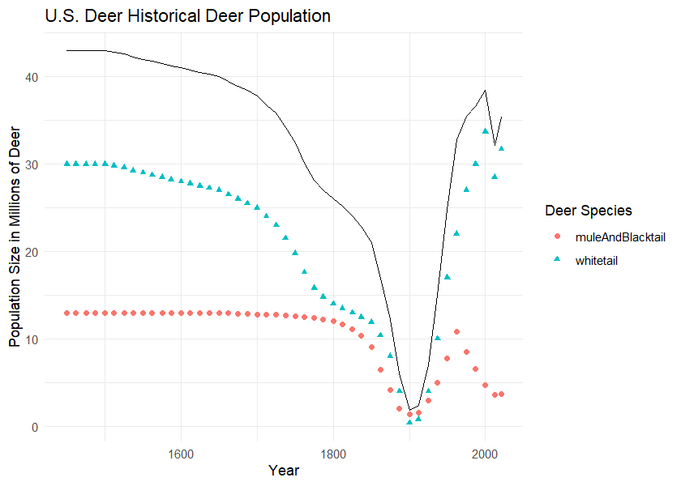

```r
ggplot(USdeerpopLong) +
  geom_point(aes(x = year, y = totalByType, colour = deerType, shape = deerType)) +
  geom_line(aes(x = year, y = totalDeer)) +
  labs(title = "U.S. Deer Historical Deer Population", shape = "Deer Species", color = "Deer Species") +
  xlab("Year") + ylab("Population Size in Millions of Deer") +
  scale_color_hue(direction = 1) +
  theme_minimal()
```

This graph visualizes the historical estimated US deer population data, with a line representing the total population and shape/color coded points depicting the populations of different species of deer.

It becomes obvious that there are and almost always have been far more white tailed deer than mule deer and black tailed deer combined.

The populations of all three of these deer species suffered near extinction around 1900. What is perhaps most interesting about this visualization is that it appears the whitetail population rebounded very successfully, while the mule deer and blacktail populations experience a much more turbulent growth, if it could be labeled much of a growth at all!

```r
# plot PAdeer with USdeer whitetails

# data
USPAwhitetails <-
  USdeerpop %>%
  select(year, whitetail) %>%
  inner_join(PAdeerharvest %>% select(year, totalDeer))

colnames(USPAwhitetails) <- c("Year", "US_Whitetails", "PA_Whitetails")
# scale for visual aid
USPAwhitetails <- USPAwhitetails %>%
  mutate(US_Whitetails = US_Whitetails * 10000)

USPAWTlong <- USPAwhitetails %>%
  pivot_longer(cols = c(US_Whitetails, PA_Whitetails),
               names_to = "scope",
               values_to = "totals")

ggplot(USPAWTlong) +
  aes(x = Year, y = totals, colour = scope) +
  geom_line() +
  scale_color_hue(direction = 1) +
    labs(title = "Scaled US Deer Pop. vs. PA Deer Harvest, Representing Population Growth", color = "Scope") +
  ylab("Scaled Population vs Harvest") +
  theme_minimal()
```

[output not shown]

This graph allows us to see the acceleration in PA Whitetail harvests relative to the growth of the estimated US Whitetail population.

I mentioned earlier how the Pennsylvania state government uses yearly harvest data to gain an understanding of the state’s current deer population. From this graph, we see that the deer population in PA has likely been accelerating at a rate faster than the national average, but also may have been more impacted by over-harvest than other states, at least in terms of white tailed deer, and assuming the current harvest data is indicative of herd size.

Pennsylvania is well-known for its Whitetails after all!

## Analysis No. 2: State-vs-State

Next, I would like to compare the harvest data out of Pennsylvania to harvest and population data from other states.

```r
# data
TxNv <- TXdeerpop %>%
  select(Year, Total) %>%
  inner_join(NVdeerpop %>% select(Year, Population))

colnames(TxNv) <- c("year", "TX", "NV")

TxNvLong <- TxNv %>%
  pivot_longer(cols = c(TX, NV),
               names_to = "state",
               values_to = "population")

ggplot(TxNvLong) +
  aes(x = year, y = population, fill = state) +
  geom_area() +
  scale_fill_hue(direction = 1) +
  labs(title = "Combined Deer Population of Texas and Nevada", subtitle = "The states with the highest and the lowest deer populations.", color = "State") +
  xlab("Year") + ylab("Total Population Size") +
  theme_minimal()
```

[output not shown]

The population of deer in Nevada seems almost entirely insignificant compared to that of Texas.

```r
# data
PaTx <- PAdeerharvest %>%
  select(year, totalDeer) %>%
  inner_join(TXdeerpop %>% select(Year, Hunt), by=c("year"="Year"))

colnames(PaTx) <- c("year", "PA", "TX")

PaTxLong <- PaTx %>%
  pivot_longer(cols = c(PA, TX),
               names_to = "state",
               values_to = "harvests")

ggplot(PaTxLong) +
  aes(x = year, y = harvests, fill = state) +
  geom_area() +
  scale_fill_hue(direction = 1) +
  labs(title = "Side-by-Side Pennsylvania and Texas Deer Harvest", fill = "State") +
  xlab("Year") + ylab("Deer Havest") +
  theme_minimal() +
  facet_wrap(vars(state))
```

[output not shown]

Around the turn of the century, the PA harvest was about four-fifths the size of the TX harvest, but is now less than half.

## Analysis No. 3: Pennsylvania Big Game

```r
PAtotals <- PAdeerharvest %>%
  select(year, totalDeer, bear, totalElk, totalTurkey) %>%
  mutate(total = totalDeer + bear + totalElk + totalTurkey)

PAbucks <- PAdeerharvest %>%
  select(year, buck) %>%
  left_join(PAtotals %>% select(year, total))

PAbucks %>%
  mutate(proportion = buck / total) %>%
  summarise(summaryProp = mean(proportion, na.rm=TRUE))
```

[output not shown]

Finally, I want to know exactly how much of Pennsylvania’s big game harvests include the iconic white-tailed buck. And here we find out that buck harvests make up 32.6% of all big game animal harvests in PA!

End of file.